# Topic 3.4: Linear Regression Model Selection

Home Price Prediction in Sacramento

Advanced Modelling, Master in Computational Social Science

UC3M, 2025-2026

# 1 Introduction

In this notebook we are going to apply some of the model selection techniques seen in topic 3.4 applied to a regression dataset. We will be trying to predict home prices in Sacramento using a dataset available in `caret`.

Recall that we will divide the ways for doing model selection in:

- **Subset selection**: choose which variables to keep
- **Regularization**: shrink coefficients with Ridge, Lasso, and Elastic Net
- **Dimensionality reduction**: replace many predictors with a smaller set of components

```r
# Load libraries
library(leaflet)
library(tidyverse)
library(caret)
library(olsrr)
library(pls)
```

# 2 Data exploration

The dataset contains 932 home sales in Sacramento, CA, corresponding to real transactions over a five-day period.

**Variables:**

- `price`: Sale price (our target $Y$)
- `beds`, `baths`, `sqft`: House characteristics
- `type`: Residential, Condo, or Multi-Family
- `latitude`, `longitude`: Location
- `city`, `zip`: Geographic identifiers

```r
# Load data
data(Sacramento)

# Explore the data
dim(Sacramento)
```

```
## [1] 932   9
```

```r
str(Sacramento)
```

```
## 'data.frame':    932 obs. of  9 variables:
##  $ city     : Factor w/ 37 levels "ANTELOPE","AUBURN",..: 34 34 34 34 34 34 34 34 29 31 ...
##  $ zip      : Factor w/ 68 levels "z95603","z95608",..: 64 52 44 44 53 65 66 49 24 25 ...
##  $ beds     : int  2 3 2 2 2 3 3 3 2 3 ...
##  $ baths    : num  1 1 1 1 1 1 2 1 2 2 ...
##  $ sqft     : int  836 1167 796 852 797 1122 1104 1177 941 1146 ...
##  $ type     : Factor w/ 3 levels "Condo","Multi_Family",..: 3 3 3 3 3 1 3 3 1 3 ...
##  $ price    : int  59222 68212 68880 69307 81900 89921 90895 91002 94905 98937 ...
##  $ latitude : num  38.6 38.5 38.6 38.6 38.5 ...
##  $ longitude: num  -121 -121 -121 -121 -121 ...
```

```r
summary(Sacramento)
```

```
##              city          zip           beds           baths
##  SACRAMENTO    :438   z95823 : 61   Min.   :1.000   Min.   :1.000
##  ELK_GROVE     :114   z95828 : 45   1st Qu.:3.000   1st Qu.:2.000
##  ROSEVILLE     : 48   z95758 : 44   Median :3.000   Median :2.000
##  CITRUS_HEIGHTS: 35   z95835 : 37   Mean   :3.276   Mean   :2.053
##  ANTELOPE      : 33   z95838 : 37   3rd Qu.:4.000   3rd Qu.:2.000
##  RANCHO_CORDOVA: 28   z95757 : 36   Max.   :8.000   Max.   :5.000
##  (Other)       :236   (Other):672
##       sqft                type         price           latitude
##  Min.   : 484   Condo       : 53   Min.   : 30000   Min.   :38.24
##  1st Qu.:1167   Multi_Family: 13   1st Qu.:156000   1st Qu.:38.48
##  Median :1470   Residential :866   Median :220000   Median :38.62
##  Mean   :1680                      Mean   :246662   Mean   :38.59
##  3rd Qu.:1954                      3rd Qu.:305000   3rd Qu.:38.69
##  Max.   :4878                      Max.   :884790   Max.   :39.02
##
##    longitude
##  Min.   :-121.6
##  1st Qu.:-121.4
##  Median :-121.4
##  Mean   :-121.4
##  3rd Qu.:-121.3
##  Max.   :-120.6
##
```

Before going further into the analysis, we will do a train/test split.

```r
set.seed(42)  # For reproducibility
in_train <- createDataPartition(Sacramento$price, p = 0.75, list = FALSE)
training <- Sacramento[in_train, ]
testing  <- Sacramento[-in_train, ]

cat("Training set:", nrow(training), "observations\n")
```

```
## Training set: 700 observations
```

```r
cat("Testing set:", nrow(testing), "observations\n")
```

```
## Testing set: 232 observations
```

We will now explore our training data to get some insights. First, lets plot the geographical distribution of our data on Sacramento, with the price in different colors. This is done using the `leaflet` package.

```r
color_pal <- colorNumeric(palette = "RdYlBu", domain = training$price, reverse=T)

map = leaflet(training) %>%
  addProviderTiles(providers$CartoDB.Positron) %>%
  setView(lng=median(training$longitude), lat=median(training$latitude), zoom = 9) %>%
  addCircles(lng = ~longitude,
             lat = ~latitude,
             radius = ~sqrt(sqft)*2,
             color = ~color_pal(price)) %>%
  addLabelOnlyMarkers(
    lng = median(training$longitude)-.6, lat = median(training$latitude)+.3,
    label = "Price and size",
    labelOptions = labelOptions(textsize = "20px", noHide = T, textOnly = T))

map %>% addLegend(position="bottomleft", pal = color_pal, values = ~price, bins=4)
```

[interactive chart not shown]

We can also have a look at the price distribution across the dataset, that looks roguhly symmetric on a log scale.

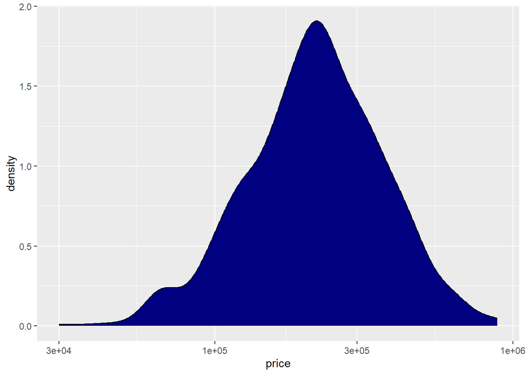

```r
training %>% ggplot(aes(x=price)) + geom_density(fill="navyblue") + scale_x_log10()
```

Before modeling, let’s compare the pairwise correlations across the numeric variables:

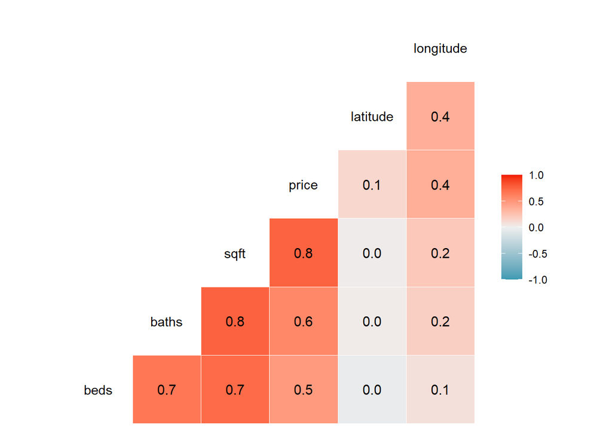

```r
GGally::ggcorr(training, label = T)
```

We can see how `sqft`, `baths` and `beds` have a quite high correlation with the price. The geographical variable `longitude` seems also to be a bit relevant, while `latitude` is not.

# 3 Regression Baseline and Modelling Setup

We will first fit a linear model with the classic approach: minimize sum of squared residuals. We use log-transformations for price and sqft to handle skewness.

```r
linFit <- lm(log(price) ~ beds + baths + log(sqft) + type + latitude*longitude, data=training)
summary(linFit)
```

```
##
## Call:
## lm(formula = log(price) ~ beds + baths + log(sqft) + type + latitude *
##     longitude, data = training)
##
## Residuals:
##      Min       1Q   Median       3Q      Max
## -1.74482 -0.19372  0.00312  0.19757  1.51341
##
## Coefficients:
##                      Estimate Std. Error t value Pr(>|t|)
## (Intercept)        -7.167e+03  4.344e+03  -1.650  0.09945 .
## beds               -5.962e-02  2.272e-02  -2.624  0.00889 **
## baths               1.576e-02  2.795e-02   0.564  0.57308
## log(sqft)           1.045e+00  5.952e-02  17.564  < 2e-16 ***
## typeMulti_Family   -2.059e-01  1.286e-01  -1.601  0.10980
## typeResidential     1.224e-01  5.848e-02   2.093  0.03674 *
## latitude            1.873e+02  1.124e+02   1.667  0.09602 .
## longitude          -5.905e+01  3.580e+01  -1.650  0.09950 .
## latitude:longitude  1.542e+00  9.258e-01   1.665  0.09629 .
## ---
## Signif. codes:  0 '***' 0.001 '**' 0.01 '*' 0.05 '.' 0.1 ' ' 1
##
## Residual standard error: 0.3248 on 691 degrees of freedom
## Multiple R-squared:  0.6216, Adjusted R-squared:  0.6173
## F-statistic: 141.9 on 8 and 691 DF,  p-value: < 2.2e-16
```

We get a value of $R^2 \approx 60\%$, but some variables are not statistically significant. This hints at **multicollinearity**, as when predictors are correlated, individual coefficients are estimated with high noise.

We can also evaluate the linear model in the test data to get the testing $R^2$:

```r
pred_linFit <- exp(predict(linFit, newdata=testing))
cat("Test R^2:", round(cor(testing$price, pred_linFit)^2, 3), "\n")
```

```
## Test R^2: 0.644
```

As we have seen, the price and area of the houses can be transformed by the log. We can also consider some other **engineered features** such as creating a ratio of beds per bath or using the squared longitude and latitude.

This can help include non linear combinations of our original variables to still use a linear model with higher flexibility. In the case of longitude and latitude, squaring them or adding their interaction can detect patterns like being far from the center. However, by doing so we might be including collinearity or loosing interpretability.

```r
# pipeline for out feature engineering
prepare_model_data <- function(df) {
  df %>%
    filter(price > 0, sqft > 0, baths > 0) %>%
    drop_na(price, beds, baths, sqft, type, city, zip, latitude, longitude) %>%
    mutate(
      bedsperbath = beds / baths,
      log_price   = log(price),
      log_sqft    = log(sqft),
      latitude2   = latitude^2,
      longitude2  = longitude^2
    )
}

# Apply pipeline to test and train
training <- prepare_model_data(training)
testing  <- prepare_model_data(testing)

# Build the full model formula with all numerical variables, their selected transformations and interaction
ModelF <- log_price ~ bedsperbath * type + log_sqft + latitude*longitude + latitude2 + longitude2

# Extract the testing log prices to compare with our predicted results
test_results <- data.frame(price = testing$log_price)

# Store model complexity (number of coefficients) with the same keys as test_results columns
model_p <- c()

# Helper to keep predictions and complexity aligned across all models
register_model <- function(name, pred, p) {
  test_results[[name]] <<- as.numeric(pred)
  model_p[[name]] <<- as.integer(p)
}

# And create a Cross Validation setup
ctrl <- trainControl(method = "repeatedcv", number = 5, repeats = 1)
```

# 4 Best Subset Selection

## 4.1 AIC and BIC

Remember that as RSS and $R^2$ always improve with more data, we need some alternative metrics such as the **AIC** (Akaike Information Criteria) or **BIC** (Bayesian Information Criteria). In both cases lower values are better.

We need to start by building a linear fill model, and then, using that model, we will get the best subset selection.

```r
# Base full model for subset selection
linFit_full <- lm(ModelF, data = training)
```

Then, we will start by the *pure* best subset selection, trying all $2^p$ combinations and picking the best by a criterion. Feasible here since $p$ is small, but in larger cases only stepwise might be feasible. Note how this following chunk takes longer than the next stepwise variations.

```r
best_subset <- ols_step_best_subset(linFit_full)
best_subset
```

```
##                                               Best Subsets Regression
## --------------------------------------------------------------------------------------------------------------------
## Model Index    Predictors
## --------------------------------------------------------------------------------------------------------------------
##      1         log_sqft
##      2         log_sqft longitude
##      3         log_sqft longitude bedsperbath:type
##      4         type log_sqft longitude bedsperbath:type
##      5         type log_sqft latitude2 bedsperbath:type latitude:longitude
##      6         type log_sqft latitude longitude bedsperbath:type latitude:longitude
##      7         type log_sqft latitude longitude latitude2 bedsperbath:type latitude:longitude
##      8         type log_sqft latitude longitude latitude2 longitude2 bedsperbath:type latitude:longitude
##      9         bedsperbath type log_sqft latitude longitude latitude2 longitude2 bedsperbath:type latitude:longitude
## --------------------------------------------------------------------------------------------------------------------
##
##                                                     Subsets Regression Summary
## ----------------------------------------------------------------------------------------------------------------------------------
##                        Adj.        Pred
## Model    R-Square    R-Square    R-Square     C(p)        AIC          SBIC         SBC        MSEP       FPE       HSP      APC
## ----------------------------------------------------------------------------------------------------------------------------------
##   1        0.5768      0.5762      0.5742    78.3959    487.4584    -1504.6755    501.1117    81.7661    0.1171    2e-04    0.4256
##   2        0.6067      0.6056      0.6034    25.6888    438.1735    -1549.9817    456.3778    76.0989    0.1092    2e-04    0.3967
##   3        0.6156      0.6128      0.6065    15.4120    428.1601    -1558.0027    460.0177    74.4848    0.1073    2e-04    0.3888
##   4        0.6204      0.6166      0.6098    10.5541    423.2893    -1558.3671    464.2490    73.6528    0.1064    2e-04    0.3850
##   5        0.6218      0.6174      0.6104    10.1199    422.8317    -1552.0380    468.3425    73.5006    0.1064    2e-04    0.3848
##   6        0.6235      0.6186      0.6109     8.9381    421.6061    -1546.4145    471.6680    73.2684    0.1062    2e-04    0.3841
##   7        0.6239      0.6185      0.6105    10.1832    422.8387    -1538.2869    477.4517    73.2941    0.1064    2e-04    0.3848
##   8        0.6240      0.6180      0.6098    12.0000    424.6524    -1529.5742    483.8164    73.3808    0.1066    2e-04    0.3858
##   9        0.6240      0.6180      0.6098    12.0000    424.6524    -1520.6779    483.8164    73.4873    0.1068    2e-04    0.3869
## ----------------------------------------------------------------------------------------------------------------------------------
## AIC: Akaike Information Criteria
##  SBIC: Sawa's Bayesian Information Criteria
##  SBC: Schwarz Bayesian Criteria
##  MSEP: Estimated error of prediction, assuming multivariate normality
##  FPE: Final Prediction Error
##  HSP: Hocking's Sp
##  APC: Amemiya Prediction Criteria
```

From the table we could select the best one based on one of the chosen metrics.

However, as this best subset approach is not feasible in bigger dimensions, we need other options.

We can use the forward selection method using the AIC with the following function, which will start with no predictors and add one at a time, keeping whichever addition reduces AIC the most:

```r
forward_AIC <- ols_step_forward_aic(linFit_full)
forward_AIC
```

```
##
##
##                                    Stepwise Summary
## -------------------------------------------------------------------------------------
## Step    Variable                AIC         SBC         SBIC         R2       Adj. R2
## -------------------------------------------------------------------------------------
##  0      Base Model            1087.392    1096.494     -898.682    0.00000    0.00000
##  1      log_sqft               487.458     501.112    -1504.675    0.57680    0.57619
##  2      longitude              438.173     456.378    -1549.982    0.60669    0.60557
##  3      type                   428.062     455.368    -1556.038    0.61454    0.61233
##  4      bedsperbath:type       423.289     464.249    -1558.367    0.62043    0.61659
##  5      latitude2              422.993     468.504    -1551.875    0.62167    0.61729
##  6      latitude:longitude     422.007     472.069    -1546.014    0.62328    0.61837
##  7      bedsperbath            422.007     472.069    -1537.135    0.62328    0.61837
## -------------------------------------------------------------------------------------
##
## Final Model Output
## ------------------
##
##                          Model Summary
## ---------------------------------------------------------------
## R                       0.789       RMSE                 0.322
## R-Squared               0.623       MSE                  0.104
## Adj. R-Squared          0.618       Coef. Var            2.641
## Pred R-Squared          0.611       AIC                422.007
## MAE                     0.246       SBC                472.069
## ---------------------------------------------------------------
##  RMSE: Root Mean Square Error
##  MSE: Mean Square Error
##  MAE: Mean Absolute Error
##  AIC: Akaike Information Criteria
##  SBC: Schwarz Bayesian Criteria
##
##                                 ANOVA
## ---------------------------------------------------------------------
##                Sum of
##               Squares         DF    Mean Square       F         Sig.
## ---------------------------------------------------------------------
## Regression    120.079          9         13.342    126.847    0.0000
## Residual       72.577        690          0.105
## Total         192.656        699
## ---------------------------------------------------------------------
##
##                                               Parameter Estimates
## ----------------------------------------------------------------------------------------------------------------
##                        model         Beta    Std. Error    Std. Beta      t        Sig         lower      upper
## ----------------------------------------------------------------------------------------------------------------
##                  (Intercept)    -1242.522       766.997                 -1.620    0.106    -2748.450    263.406
##                     log_sqft        0.950         0.036        0.707    26.552    0.000        0.880      1.021
##                    longitude      -21.039        12.596       -5.642    -1.670    0.095      -45.770      3.692
##             typeMulti_Family       -1.261         0.454       -0.271    -2.776    0.006       -2.152     -0.369
##              typeResidential       -0.246         0.153       -0.118    -1.604    0.109       -0.546      0.055
##                    latitude2        0.881         0.512       16.874     1.721    0.086       -0.124      1.886
##                  bedsperbath       -0.269         0.099       -0.281    -2.726    0.007       -0.464     -0.075
## typeMulti_Family:bedsperbath        0.649         0.272        0.236     2.387    0.017        0.115      1.183
##  typeResidential:bedsperbath        0.252         0.102        0.328     2.478    0.013        0.052      0.452
##           longitude:latitude        0.559         0.325       15.695     1.717    0.086       -0.080      1.198
## ----------------------------------------------------------------------------------------------------------------
```

```r
register_model(
  name = "forward_AIC",
  pred = predict(forward_AIC$model, newdata = testing),
  p = length(coef(forward_AIC$model))
)
postResample(pred = test_results$forward_AIC, obs = test_results$price)
```

```
##      RMSE  Rsquared       MAE
## 0.3330116 0.6044591 0.2524240
```

We have other options, as we saw in class such as the backwards selection, or we can combine them using both forward and backwards selection with the following function, which specifies when a variable is added or removed by `(+)` or `(-)`

```r
both_AIC <- ols_step_both_aic(linFit_full)
both_AIC
```

```
##
##
##                                      Stepwise Summary
## -----------------------------------------------------------------------------------------
## Step    Variable                    AIC         SBC         SBIC         R2       Adj. R2
## -----------------------------------------------------------------------------------------
##  0      Base Model                1087.392    1096.494     -898.682    0.00000    0.00000
##  1      log_sqft (+)               487.458     501.112    -1504.675    0.57680    0.57619
##  2      longitude (+)              438.173     456.378    -1549.982    0.60669    0.60557
##  3      type (+)                   428.062     455.368    -1556.038    0.61454    0.61233
##  4      bedsperbath:type (+)       423.289     464.249    -1558.367    0.62043    0.61659
##  5      latitude2 (+)              422.993     468.504    -1551.875    0.62167    0.61729
##  6      latitude:longitude (+)     422.007     472.069    -1546.014    0.62328    0.61837
##  7      bedsperbath (+)            422.007     472.069    -1537.135    0.62328    0.61837
## -----------------------------------------------------------------------------------------
##
## Final Model Output
## ------------------
##
##                          Model Summary
## ---------------------------------------------------------------
## R                       0.789       RMSE                 0.322
## R-Squared               0.623       MSE                  0.104
## Adj. R-Squared          0.618       Coef. Var            2.641
## Pred R-Squared          0.611       AIC                422.007
## MAE                     0.246       SBC                472.069
## ---------------------------------------------------------------
##  RMSE: Root Mean Square Error
##  MSE: Mean Square Error
##  MAE: Mean Absolute Error
##  AIC: Akaike Information Criteria
##  SBC: Schwarz Bayesian Criteria
##
##                                 ANOVA
## ---------------------------------------------------------------------
##                Sum of
##               Squares         DF    Mean Square       F         Sig.
## ---------------------------------------------------------------------
## Regression    120.079          9         13.342    126.847    0.0000
## Residual       72.577        690          0.105
## Total         192.656        699
## ---------------------------------------------------------------------
##
##                                               Parameter Estimates
## ----------------------------------------------------------------------------------------------------------------
##                        model         Beta    Std. Error    Std. Beta      t        Sig         lower      upper
## ----------------------------------------------------------------------------------------------------------------
##                  (Intercept)    -1242.522       766.997                 -1.620    0.106    -2748.450    263.406
##                     log_sqft        0.950         0.036        0.707    26.552    0.000        0.880      1.021
##                    longitude      -21.039        12.596       -5.642    -1.670    0.095      -45.770      3.692
##             typeMulti_Family       -1.261         0.454       -0.271    -2.776    0.006       -2.152     -0.369
##              typeResidential       -0.246         0.153       -0.118    -1.604    0.109       -0.546      0.055
##                    latitude2        0.881         0.512       16.874     1.721    0.086       -0.124      1.886
##                  bedsperbath       -0.269         0.099       -0.281    -2.726    0.007       -0.464     -0.075
## typeMulti_Family:bedsperbath        0.649         0.272        0.236     2.387    0.017        0.115      1.183
##  typeResidential:bedsperbath        0.252         0.102        0.328     2.478    0.013        0.052      0.452
##           longitude:latitude        0.559         0.325       15.695     1.717    0.086       -0.080      1.198
## ----------------------------------------------------------------------------------------------------------------
```

```r
register_model(
  name = "both_AIC",
  pred = predict(both_AIC$model, newdata = testing),
  p = length(coef(both_AIC$model))
)
postResample(pred = test_results$both_AIC, obs = test_results$price)
```

```
##      RMSE  Rsquared       MAE
## 0.3330116 0.6044591 0.2524240
```

Many other options are available in the `olsrr` package, such as `olsrr::ols_step_both_adj_r2()` or `olsrr::ols_step_both_sbic()` using different criteria than the AIC.

## 4.2 Cross-Validated Stepwise Selection

The `olsrr` output is useful for inspection and choosin by a given metric such as the AIC, but we can also tune the subset size directly with cross-validation:

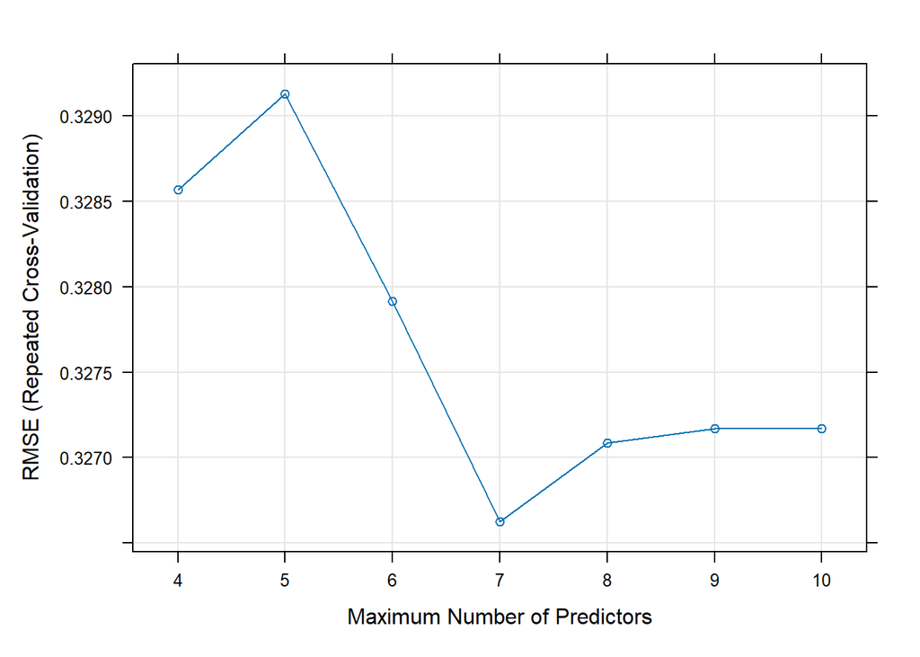

```r
# The leapForward method does Forward Stepwise selection, and nvmax controls the maximum number of predictors
# Other methods are available, such as leapBackward
for_tune <- train(ModelF, data = training,
                  method = "leapForward",
                  preProc = c('nzv','scale', 'center'),
                  tuneGrid = expand.grid(nvmax = 4:10),
                  trControl = ctrl)
plot(for_tune)
```

```r
cat("Best number of variables:", for_tune$bestTune$nvmax, "\n")
```

```
## Best number of variables: 7
```

```r
coef(for_tune$finalModel, for_tune$bestTune$nvmax)
```

```
##                 (Intercept)                 bedsperbath
##                 12.28174142                 -0.11875202
##             typeResidential                    log_sqft
##                 -0.03139544                  0.36576542
##                   longitude                   latitude2
##                 -3.12809892                  9.34376696
## bedsperbath:typeResidential          latitude:longitude
##                  0.13441619                  8.69002304
```

```r
register_model(
  name = "forward_CV",
  pred = predict(for_tune, testing),
  p = length(coef(for_tune$finalModel, for_tune$bestTune$nvmax))
)
postResample(pred = test_results$forward_CV, obs = test_results$price)
```

```
##      RMSE  Rsquared       MAE
## 0.3255834 0.6215043 0.2455126
```

> Remember that when using any of these methods and a validation dataset, if we select a model as our final one, we could retrain it with the full training data

# 5 Regularization

Now let’s see the regularization techniques, where a penalty term is included in the OLS objective to shrink coefficients and reduce variance:

$$\min_\beta \text{RSS}(\beta)+ \lambda
\cdot \text{Penalty}(\beta)$$

The tuning parameter $\lambda$ controls the strength: $\lambda = 0$ gives OLS, larger $\lambda$ shrinks more.

We reuse the shared setup above and let `caret` tune the penalty parameters with cross-validation.

## 5.1 Ridge Regression ($L_2$ penalty)

Ridge **shrinks all coefficients toward zero** but never sets any to exactly zero:

$$\text{Penalty} = \|\beta\|_2^2 =
\sum_{j=1}^p \beta_j^2$$

We start with a broad option of values for lambda in log scale, and then we can repeat the process with more lambda values around the best lambda region.

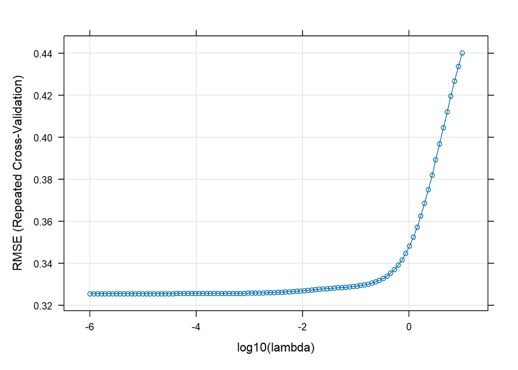

```r
ridge_grid <- expand.grid(lambda = 10^seq(-6, 1, length.out = 100)) # The lambda values can change a lot for different problems

ridge_tune <- train(ModelF, data = training,
                    method = 'ridge',
                    preProc = c('scale', 'center'),
                    tuneGrid = ridge_grid,
                    trControl = ctrl)
plot(ridge_tune, xTrans = log10, xlab = "log10(lambda)")
```

```r
cat("Best lambda:", ridge_tune$bestTune$lambda, "\n")
```

```
## Best lambda: 3.125716e-06
```

In this case we see that the best CV result is obtained for a very small $\lambda$ value. (The weight decay value is our $\lambda$).

Lets try again with more values around that lambda:

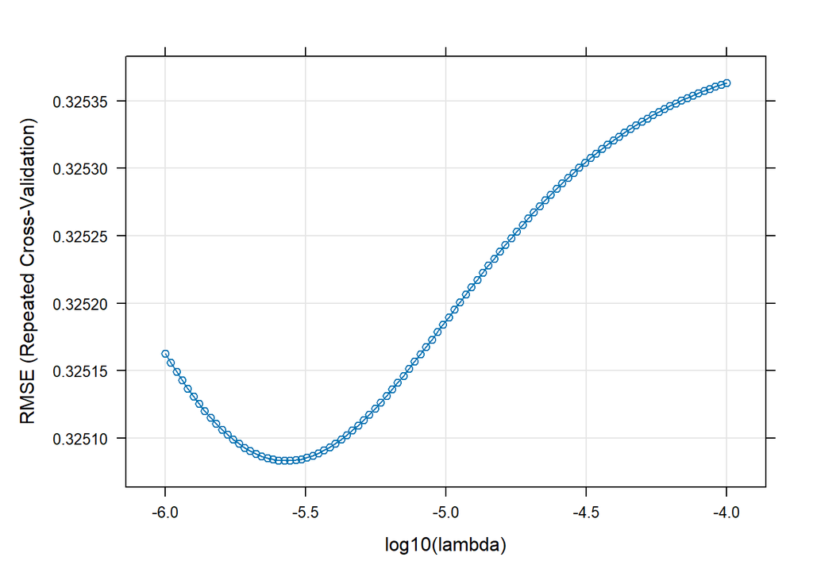

```r
ridge_grid <- expand.grid(lambda = 10^seq(-6, -4, length.out = 100)) # The lambda values can change a lot for different problems

ridge_tune <- train(ModelF, data = training,
                    method = 'ridge',
                    preProc = c('scale', 'center'),
                    tuneGrid = ridge_grid,
                    trControl = ctrl)
plot(ridge_tune, xTrans = log10, xlab = "log10(lambda)")
```

```r
cat("Best lambda:", ridge_tune$bestTune$lambda, "\n")
```

```
## Best lambda: 2.656088e-06
```

```r
register_model(
  name = "ridge",
  pred = predict(ridge_tune, testing),
  p = length(attr(ridge_tune$terms,"term.labels"))
)
postResample(pred = test_results$ridge, obs = test_results$price)
```

```
##      RMSE  Rsquared       MAE
## 0.3328327 0.6043046 0.2520615
```

## 5.2 Lasso ($L_1$ penalty)

Lasso **sets some coefficients to exactly zero**, doing automatic variable selection:

$$\text{Penalty} = \|\beta\|_1 =
\sum_{j=1}^p |\beta_j|$$
In this case the caret method controls the penalization by setting a “fraction” of the full solution, so that parameter can go between 0 an 1, and in that case 1 represents the full model with no shrinkage

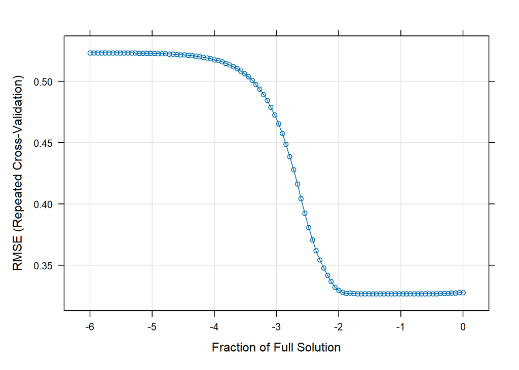

```r
lasso_grid <- expand.grid(fraction = 10^seq(-6, 0, length.out = 100))

lasso_tune <- train(ModelF, data = training,
                    method = 'lasso',
                    preProc = c('scale', 'center'),
                    tuneGrid = lasso_grid,
                    trControl = ctrl)
plot(lasso_tune, xTrans = log10)
```

```r
cat("Best lambda:", lasso_tune$bestTune$fraction, "\n")
```

```
## Best lambda: 0.1417474
```

```r
register_model(
  name = "lasso",
  pred = predict(lasso_tune, testing),
  p = length(attr(lasso_tune$terms,"term.labels"))
)
postResample(pred = test_results$lasso, obs = test_results$price)
```

```
##      RMSE  Rsquared       MAE
## 0.3328317 0.6042550 0.2520295
```

Other regularization methods such as elastic net can also be used with caret; the method `glmnet` provides an implementation for it.

# 6 Dimensionality Reduction

Instead of choosing a subset of variables, we can replace the original predictors with a smaller number of components.

Before doing so, we can prepare our data to be used with the `pcr` and `plsr` formulas, which require some extra pre-processing:

```r
# First, build the data matrices with the full model formula
# This creates a matrix with a column per each term in our model, including interactions or transformed variables
# The -1 removes the intercept column, that would be full of 1s
x_train_dr <- model.matrix(ModelF, data = training)[, -1, drop = FALSE]
x_test_dr  <- model.matrix(ModelF, data = testing)[, -1, drop = FALSE]

# Standardize the data
pp <- preProcess(x_train_dr, method = c("center", "scale"))
x_train_dr <- predict(pp, x_train_dr)
x_test_dr  <- predict(pp, x_test_dr)

#  Build dataframes
pcr_train_df <- data.frame(log_price = training$log_price, x_train_dr, check.names = FALSE)
pcr_test_df  <- data.frame(x_test_dr, check.names = FALSE)
```

## 6.1 Principal Components Regression (PCR)

PCR uses PCA in a supervised workflow: first build principal components from the predictors, then regress `log(price)` on the first $M$ components.

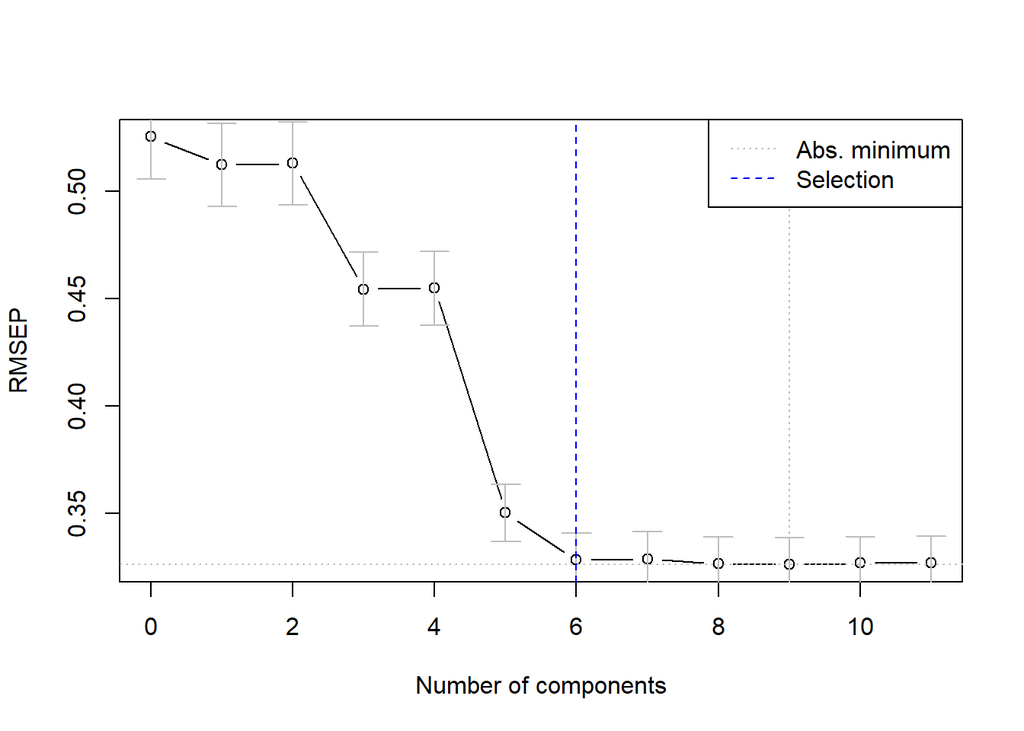

```r
pcr_fit <- pcr(log_price ~ .,
               data = pcr_train_df,
               scale = FALSE, validation = "CV")

pcr_cv <- drop(RMSEP(pcr_fit, estimate = "CV")$val[1, 1, -1])
pcr_ncomp <- pls::selectNcomp(pcr_fit, method = "onesigma", plot = TRUE)
```

```r
cat("Best number of components (PCR):", pcr_ncomp, "\n")
```

```
## Best number of components (PCR): 6
```

```r
register_model(
  name = "pcr",
  pred = drop(predict(pcr_fit, newdata = pcr_test_df, ncomp = pcr_ncomp)),
  p = pcr_ncomp + 1
)
postResample(pred = test_results$pcr, obs = test_results$price)
```

```
##      RMSE  Rsquared       MAE
## 0.3275657 0.6157384 0.2469572
```

## 6.2 Partial Least Squares (PLS)

PLS also builds components, but unlike PCR it uses the response while constructing them. That is why PLS often reaches good predictive performance with fewer components.

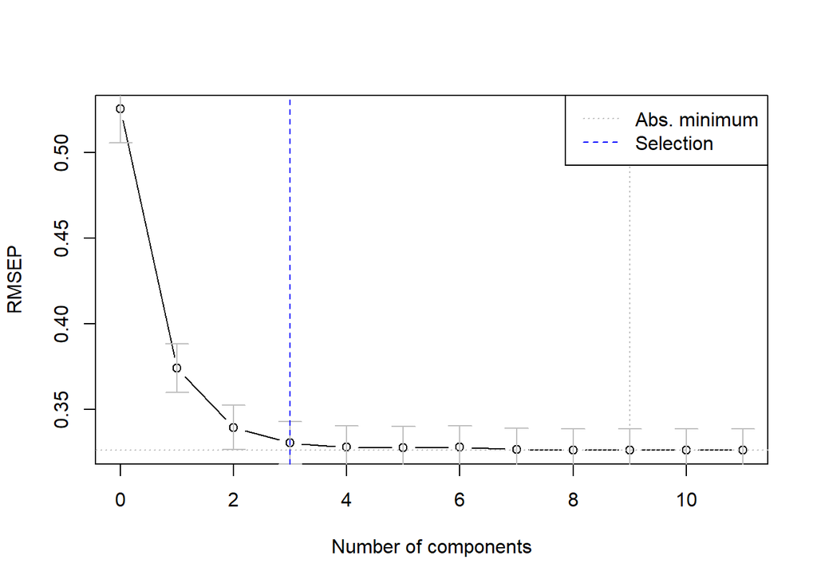

```r
pls_fit <- plsr(log_price ~ .,
                data = pcr_train_df,
                scale = FALSE, validation = "CV")

pls_cv <- drop(RMSEP(pls_fit, estimate = "CV")$val[1, 1, -1])
pls_ncomp <- pls::selectNcomp(pls_fit, method = "onesigma", plot = TRUE)
```

```r
cat("Best number of components (PLS):", pls_ncomp, "\n")
```

```
## Best number of components (PLS): 3
```

```r
register_model(
  name = "pls",
  pred = drop(predict(pls_fit, newdata = pcr_test_df, ncomp = pls_ncomp)),
  p = pls_ncomp + 1
)
postResample(pred = test_results$pls, obs = test_results$price)
```

```
##      RMSE  Rsquared       MAE
## 0.3301934 0.6091821 0.2493416
```

# 7 Summary

We can finally compare the obtained results by getting, as an example, the MAE for all models:

```r
# Mean Absolute Error for all models
mae_results <- apply(test_results[-1], 2, function(x) mean(abs(x - test_results$price)))
sort(mae_results)
```

```
##  forward_CV         pcr         pls       lasso       ridge forward_AIC
##   0.2455126   0.2469572   0.2493416   0.2520295   0.2520615   0.2524240
##    both_AIC
##   0.2524240
```

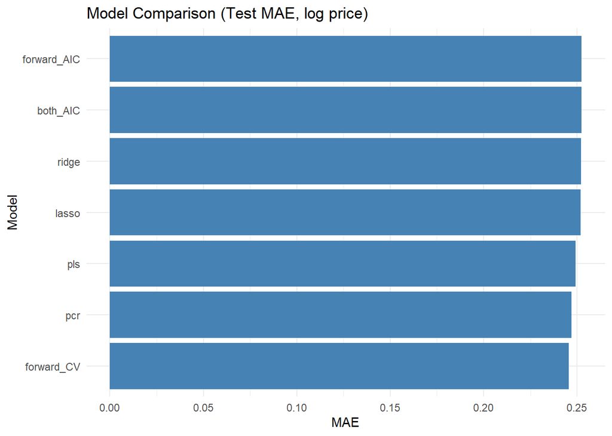

```r
mae_df <- data.frame(Model = names(mae_results), MAE = mae_results)
ggplot(mae_df, aes(x = reorder(Model, MAE), y = MAE)) +
  geom_bar(stat = "identity", fill = "steelblue") +
  coord_flip() +
  labs(title = "Model Comparison (Test MAE, log price)", x = "Model", y = "MAE") +
  theme_minimal()
```

And if we want to also compare other metrics or the number of predictors (complexity), we can see it in this table:

```r
rmse_results <- apply(test_results[-1], 2, function(x) {
  sqrt(mean((x - test_results$price)^2))
})
r2_results <- apply(test_results[-1], 2, function(x) {
  cor(x, test_results$price)^2
})

# Get model complexity aligned with prediction columns
num_coef_results <- as.numeric(model_p[names(mae_results)])

# Adjusted R2 computed on test performance and penalized by model size:
# Adj_R2 = 1 - (1 - R2) * (n - 1) / (n - k - 1), where k excludes intercept
n_test <- nrow(testing)
k_predictors <- pmax(num_coef_results - 1, 0)
adj_r2_results <- mapply(function(r2, k) {
  if (is.na(r2) || is.na(k) || n_test <= (k + 1)) return(NA_real_)
  1 - (1 - r2) * (n_test - 1) / (n_test - k - 1)
}, r2_results, k_predictors)

summary_table <- data.frame(
  Num_Coefficients = as.integer(num_coef_results),
  MAE              = round(mae_results, 4),
  RMSE             = round(rmse_results, 4),
  R2               = round(r2_results, 4),
  Adj_R2           = round(adj_r2_results,4)
)
summary_table <- summary_table[order(summary_table$MAE), ]

tbl_format <- if (knitr::is_latex_output()) "latex" else "html"

tbl <- knitr::kable(
  summary_table,
  format = tbl_format,
  booktabs = (tbl_format == "latex"),
  caption = "Model comparison on the test set (log-price scale)",
  align = "cccc"
)

tbl <- tbl %>%
  kableExtra::kable_styling(bootstrap_options = c("striped", "hover", "bordered"))

print(tbl)
```

Model comparison on the test set (log-price scale)

|  | Num_Coefficients | MAE | RMSE | R2 | Adj_R2 |
| --- | --- | --- | --- | --- | --- |
| forward_CV | 8 | 0.2455 | 0.3256 | 0.6215 | 0.6097 |
| pcr | 7 | 0.2470 | 0.3276 | 0.6157 | 0.6055 |
| pls | 4 | 0.2493 | 0.3302 | 0.6092 | 0.6040 |
| lasso | 9 | 0.2520 | 0.3328 | 0.6043 | 0.5901 |
| ridge | 9 | 0.2521 | 0.3328 | 0.6043 | 0.5901 |
| forward_AIC | 10 | 0.2524 | 0.3330 | 0.6045 | 0.5884 |
| both_AIC | 10 | 0.2524 | 0.3330 | 0.6045 | 0.5884 |